# Analysing what occurs on a person’s daily walk

## What am I actually analysing?

From Project 2 in STATS 220, I created a survey to ask people what happens in their daily walks. I asked what time they have their daily walks, the type of weather, how crowded was the walk, whether they observed joggers or not, and how many people they saw walking pets. As a result, I created 3 visualisations to find some insights and summarise what occurs on these daily walks.

## How many people were seen exercising during the daily walk?

Imagine yourself having your daily walk. Perhaps you are listening to your favourite music or podcast or nothing at all. You are appreciating and embracing your surroundings, but then suddenly someone runs past you saying a cheeky hello along the way. Well, I asked people how many times did that happen to them during their anticipated daily walks. In this case, I am analysing how many yes’s and no’s there were. The x-axis is a logical variable with levels ‘yes’ and ‘no’ while the y-axis is the number of observations which is numeric. Here is a summary of what I found:

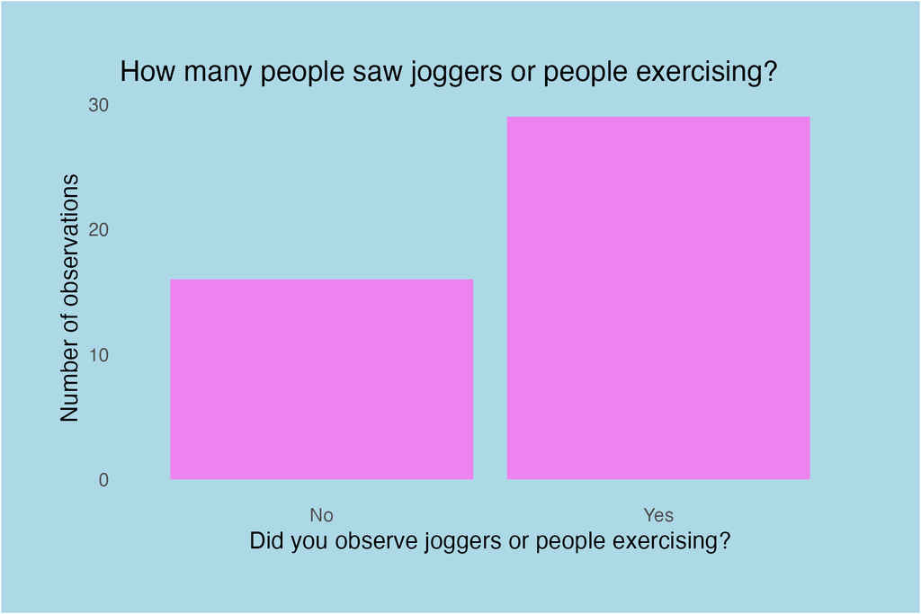

A plot with 2 columns with labels ‘yes’ and ‘no’ on the x axis and the number of observations label on the y axis. The column labelled ‘yes’ is higher than the column labeled ‘no’. This indicates that more people were seen jogging or exercising than not

Wait I might be lying! Through the visualisation shown above, 16 people did not see anyone run past them saying hi along the way. On the other hand, 29 people did see at least one person running past them. In this very small sample size, it does seem like people are keen on running than not.

## How many people walked their pets on rainy days compared to not rainy days?

Have you ever seen a wet dog in the wild? Perhaps even a wet cat? Well, it seems intuitive to keep your pets inside when it is a rainy day. Let’s inspect what people had to say about the number of pets they have seen during a rainy day during their walks. In this case, I am analysing the logical variable “is it rainy during your daily walk” on the x-axis and on the y-axis, the number of people seen walking their pets which is numeric. Here is what I found:

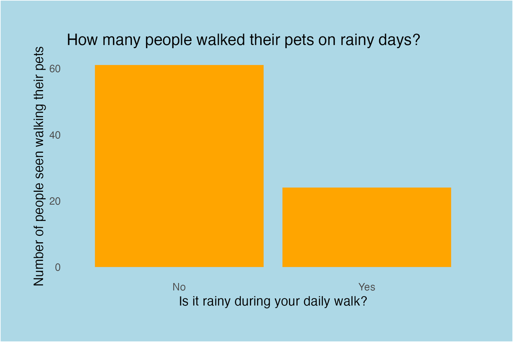

Seems like most people are pretty conscious of their pets with regards to the weather. Via the plot above, 61 people were seen walking their pets on days NOT rainy. However, 24 people were seen walking their pets on a rainy day.

## How did the number of pets seen being walked changed over time?

How has the number of pets being seen walked change over time? The time is the timestamp in which the survey was completed. The variable Timestamp on the x-axis is in date-time format and the y-axis is the number of people seen walking their pets which is numeric. As a result, I utilised a line graph for visualisation. Here is what I found:

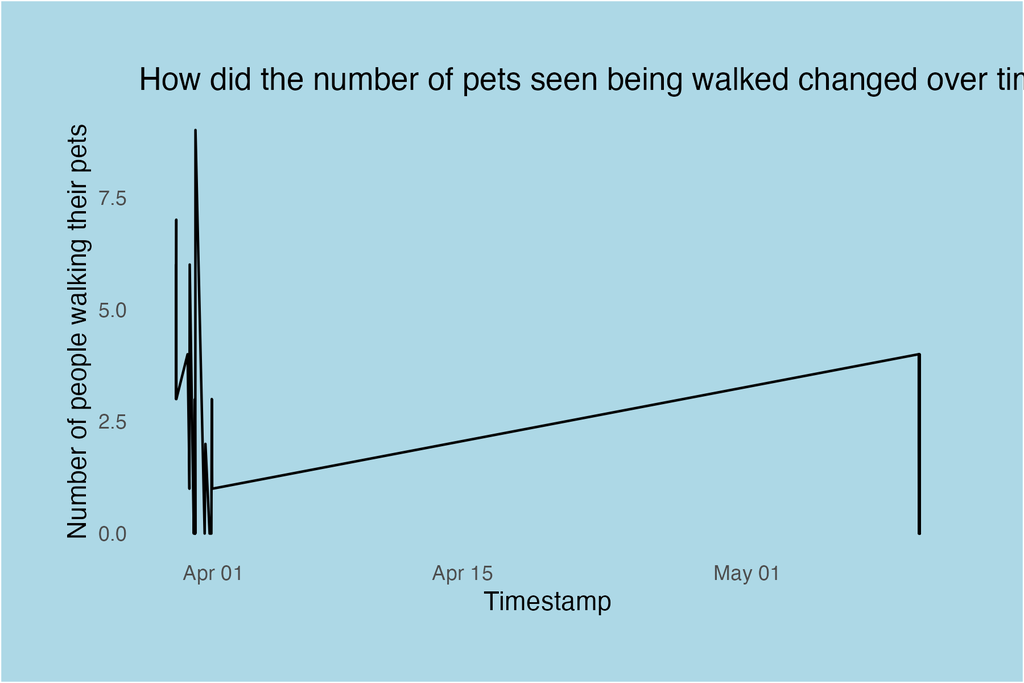